# Spotting the Difference

Matt Kumar

2020-11-10

# Intro

In this guide, I’ll share my learnings on how to leverage `diffdf` and `flextable` to spot differences between two data frames. I provide a real world use case that builds on the concepts presented at the end.

# From Scratch

I’ll begin by creating two data frames that have slight differences. Assume that the cell values between the two data frames can differ while the number of observations (rows) and variables (columns) are similar.

```r
library(flextable)
library(diffdf)
library(dplyr)

df1 <- data.frame(id  = 1:5,
                  sex = c('m','f','f','m','f'),
                  smk = c('former','never','current','current','never'))

df2 <- data.frame(id  = 1:5,
                  sex = c('f','f','f','m','f'),
                  smk = c('former','never','current','former','never'))
```

We can create a flextable for each data frame quite easily.

```r
df1 %>% flextable()
```

| id | sex | smk |
| --- | --- | --- |
| 1 | m | former |
| 2 | f | never |
| 3 | f | current |
| 4 | m | current |
| 5 | f | never |

```r
df2 %>% flextable()
```

| id | sex | smk |
| --- | --- | --- |
| 1 | f | former |
| 2 | f | never |
| 3 | f | current |
| 4 | m | former |
| 5 | f | never |

# Comparing with diffdf

The `diffdf` package can be used to find and return differences between two data frames.

Below I create an object named `deltas` that will store the results of the `diffdf()` call on the two data frames. I’ve specified that df1 is the base (or “original”) and that df2 is the comparator.

```r
deltas <- diffdf(base=df1, compare=df2)
```

The cell differences between the two data frames are stored in `deltas` as tibbles and are index by variable.

You may access them like so:

```r
#cell differences that involve the variable sex
deltas$VarDiff_sex
```

```
# A tibble: 1 x 4
  VARIABLE ..ROWNUMBER.. BASE  COMPARE
* <chr>            <int> <chr> <chr>
1 sex                  1 m     f
```

```r
#cell differences that involve the variable smk
deltas$VarDiff_smk
```

```
# A tibble: 1 x 4
  VARIABLE ..ROWNUMBER.. BASE    COMPARE
* <chr>            <int> <chr>   <chr>
1 smk                  4 current former
```

Within each tibble, the value of `VARIABLE` gives a natural column index, while the value of `..ROWNUMBER..` gives a row index. Together, these form coordinates that provide us a road map of precisely which cells in df2 differ from those in df1.

Now, we need to extract, clean and store each variables results so that this information can be readily used for styling. In this example, I use a loop to account for many variables at once. My end result is stored in `delta_data`.

```r
#get variable names
var_list <- colnames(df1)

#create a place holder
delta_list <- list()

#iterate over variables to find if cell differences was detected - get "coordinates"
for(i in var_list) {
  dat <- data.frame(eval(parse(text=paste0("deltas$VarDiff_",i)))) %>%
    janitor::clean_names()
  delta_list[[i]] <- dat
}

#put all found cell difference coordinates into a single data frame
delta_data = do.call(rbind, delta_list)

#view results
delta_data
```

```
    variable rownumber    base compare
sex      sex         1       m       f
smk      smk         4 current  former
```

# Styling Differences

We can now use `delta_data` to style the flextable for df2. Below are a few examples of how one might do this.

My general approach to styling is to iterate over the rows of coordinates in `delta_data`.

## Background colors

Change the background color for cells that differ.

```r
df2 %>%
  flextable() %>%
  #Style rows individually from delta_data
  (function(x){
    for (i in 1:nrow(delta_data)) {
      #bg() is the flextable styling function
      x <- bg(x,
              i=delta_data$rownumber[[i]],
              j=delta_data$variable[[i]],
              bg="yellow",
              part="body")}
    x
  })()
```

| id | sex | smk |
| --- | --- | --- |
| 1 | f | former |
| 2 | f | never |
| 3 | f | current |
| 4 | m | former |
| 5 | f | never |

Here is df1 again for comparisons.

```r
df1 %>%
  flextable()
```

| id | sex | smk |
| --- | --- | --- |
| 1 | m | former |
| 2 | f | never |
| 3 | f | current |
| 4 | m | current |
| 5 | f | never |

## Cell Borders

Adding a border around cells that differ. Note: This requires the `officer` package. `officer` and `flextable` actually complement each other really well and I suggest you check it out for your work flows!

```r
library(officer)

df2 %>%
  flextable() %>%
  #Style rows individually from delta_data
  (function(x){
    for (i in 1:nrow(delta_data)) {
      #border() is the flextable styling function
      x <- border(x,
              i=delta_data$rownumber[[i]],
              j=delta_data$variable[[i]],
              #fp_border() is from officer
              border=fp_border(color = "orange", style="dashed", width=1.5),
              part="body")
      }
    x
  })()
```

| id | sex | smk |
| --- | --- | --- |
| 1 | f | former |
| 2 | f | never |
| 3 | f | current |
| 4 | m | former |
| 5 | f | never |

## Font Color

You can change the font color in a very similar way.

```r
df2 %>%
  flextable() %>%
  #Style rows individually from delta_data
  (function(x){
    for (i in 1:nrow(delta_data)) {
      #color() is the flextable styling function
      x <- color(x,
              i=delta_data$rownumber[[i]],
              j=delta_data$variable[[i]],
              color="red",
              part="body")
      }
    x
  })()
```

| id | sex | smk |
| --- | --- | --- |
| 1 | f | former |
| 2 | f | never |
| 3 | f | current |
| 4 | m | former |
| 5 | f | never |

## Combining Styles

It’s straight forward to combine or stack styles using the pipe operator.

```r
df2 %>%
  flextable() %>%
  #Style rows individually from delta_data
  (function(x){
    for (i in 1:nrow(delta_data)) {
      #piping together two flextable styling functions
      x <- border(x,
              i=delta_data$rownumber[[i]],
              j=delta_data$variable[[i]],
              border=fp_border(color = "black", style="dashed", width=1.5),
              part="body") %>%
           bg(x,
                i=delta_data$rownumber[[i]],
                j=delta_data$variable[[i]],
                bg="skyblue",
                part="body")
      }
    x
  })()
```

| id | sex | smk |
| --- | --- | --- |
| 1 | f | former |
| 2 | f | never |
| 3 | f | current |
| 4 | m | former |
| 5 | f | never |

# Extensions

The examples presented for in this tutorial were kept simple for demonstration purposes. Going beyond, the combination of `diffdf` and `flextable` together seem to have the potential to form a powerful work flow tool.

### diffdf

In addition to finding individual cell differences, you can also use `diffdf` to return other useful information such as the presence or absence of columns and rows. More examples can be found in the package [vignette.](https://cran.r-project.org/web/packages/diffdf/vignettes/diffdf-basic.html)

### flextable

In flextable, you can use a variety of formatting techniques to draw attention to differences. I’ve attempted to demonstrate a few of them, and you can view other appraoches [here.](https://davidgohel.github.io/flextable/articles/format.html) I found it very straight forward to test, adapt and combine different approaches due to the intuitive design of flextable.

# Use Case

As part of my current role, I receieve pre-computed statistical tables that are saved as data sets (e.g. .sas7bdat, .csv). I import these into R as data frames for further processing.

Given that this work flow is well established, I looked at whether comparisons between statistical tables were feasible with the approach outlined in this tutorial. One of the primary aims would be to detect changes between versions of pre-computed statistical tables.

In the first panel, I have the initial version of a table.

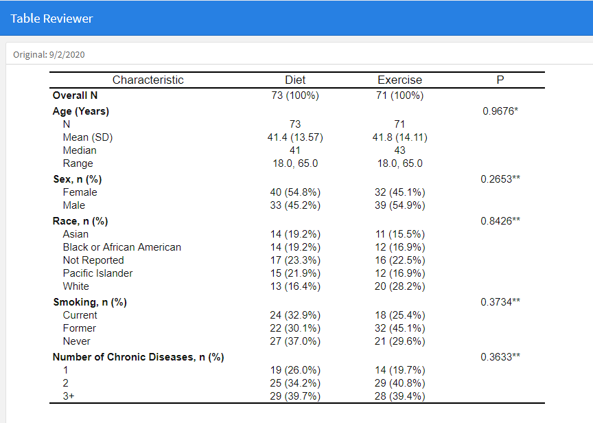

In the second panel, I have an updated version of a table.

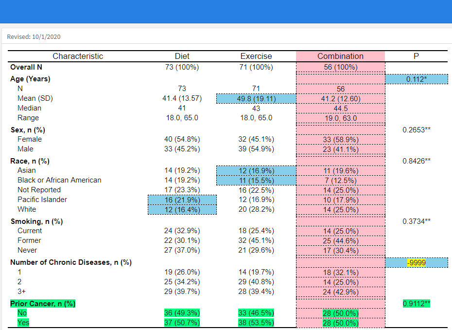

I’ve setup the following schema to highlight differences:

- Cell differences have a sky blue background with a border
- New columns have a pink background with a border
- New rows have text highlighted in green
- I have a hardcoded a rule to highlight the prescence of `-9999` in the `P` column in yellow.
  - The background for this cell is blue, because this cell value is also different from the original table.

If you are interested in the code for this example, you can view some of my progress [here](https://github.com/mattkumar/flexdiff).

I’d like to thank my colleague Robert (R.A) for the inspiration to scale my learnings into something potentially useful across our team.

Matt

# Use Case App

2020-11-10: Since publishing this original tutorial, we’ve made some progress in porting the use case into an app!

In the panel below, we have an interface that let’s the user specify which kinds of differences should be highlighted and by which color. The eventual goal is give the user the ability to specify their own tables.

Click the image to enlarge.

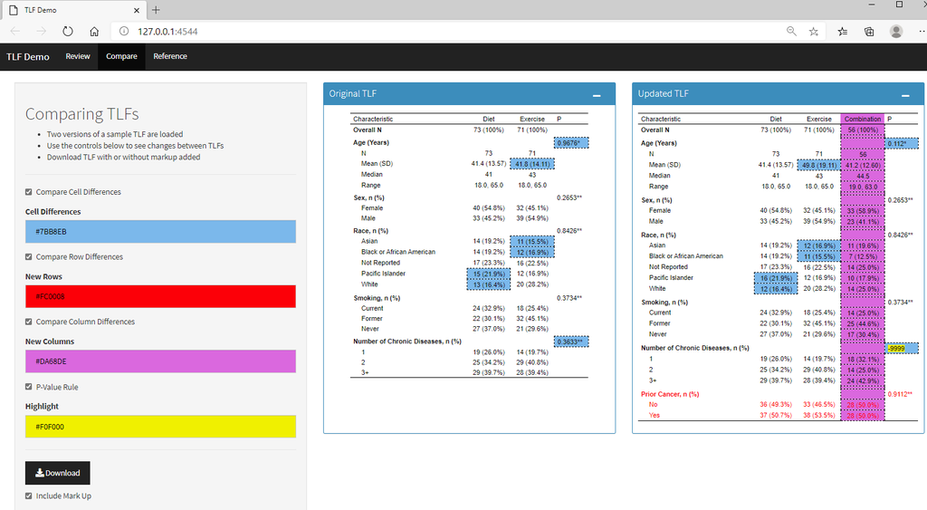

Once the tables are reviewed, I offer a download button to provide the user an offline version of the updated table as a word document (.docx). There is a check box that allows the user to specify whether the “markup” should be retained. Below is a screen shot of the downloaded document.

Click the image to enlarge.

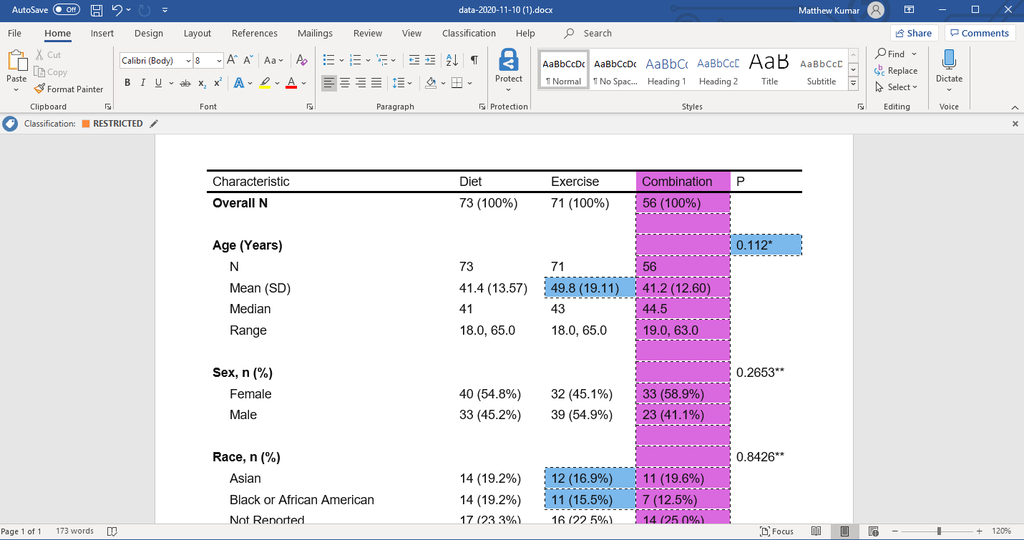

Please stay tuned for future developments. I hope to be able to post the code related to this progress very soon! In the meantime, you can still view the guts [here.](https://github.com/mattkumar/flexdiff)